# Asociación, covarianza y correlación

Sesión del miércoles, 23 de septiembre de 2026

[Ejercita R · Social R interactivo ↗](https://karavena.github.io/social-r/)

[Recurso complementario · Estadística Correlacional Interactiva ↗](https://karavena.github.io/estadistica-social/modules/m08_asociacion_covarianza_correlacion_pearson.html)

# 1 Asociación entre dos variables

Hasta ahora hemos trabajado principalmente con **diferencias entre grupos**. Ahora cambia la pregunta: en vez de comparar dos grupos, queremos saber si los valores de **dos variables** tienden a presentar algún patrón conjunto.

Trabajaremos con datos reales de la **Encuesta CASEN 2024**. Para facilitar el trabajo durante el práctico, utilizaremos una submuestra aleatoria reproducible de **1.000 personas ocupadas con información completa en las tres variables analizadas**. Esa misma submuestra se utilizará durante todo el práctico.

Nuestra pregunta principal será:

> **¿En qué medida los años de escolaridad y el ingreso de la ocupación principal se encuentran asociados?**

| Variable | Qué representa |
| --- | --- |
| `escolaridad` | Años de escolaridad |
| `ingreso_laboral` | Ingreso de la ocupación principal, en pesos |
| `horas_trabajo` | Horas trabajadas habitualmente por semana en la actividad principal |

**ImportanteLa regla del práctico**

Primero miramos el patrón entre las variables y después lo resumimos con una medida de asociación.

$$\text{Mirar}
\rightarrow
\text{anticipar}
\rightarrow
\text{calcular}
\rightarrow
\text{volver a mirar}$$

**Preparemos los datos**

Trabajaremos con la base oficial de **CASEN 2024**. R puede cargarla directamente desde el sitio del Ministerio de Desarrollo Social y Familia, por lo que no necesitamos descargar el archivo manualmente.

Primero cargamos solamente los tres paquetes que utilizaremos durante el práctico:

```r
library(dplyr)    # Para trabajar con los datos
library(ggplot2)  # Para crear gráficos
library(haven)  # Para trabajar con las etiquetas de CASEN
```

La dirección del archivo oficial se asigna en el objeto `url_casen`. Luego `load()` abre la base directamente desde Internet. Podemos leer `<-` como **“guardar como”**.

```r
url_casen <- "https://bid-ckan.ministeriodesarrollosocial.gob.cl/dataset/105286d9-10a8-410a-b060-a335f3168a46/resource/cacc6ad5-fca1-4476-82f1-b7ea119fae98/download/casen_2024.rdata"  # Dirección oficial de CASEN 2024

load(
  url(url_casen)  # Carga la base directamente desde Internet
)
```

El archivo crea en R un objeto llamado `casen_2024`, que contiene la base original. Para este práctico solo necesitamos tres variables y trabajaremos con una submuestra de 1.000 personas.

```r
set.seed(2026)  # Hace que todas y todos obtengamos los mismos casos

datos <- casen_2024 |>                                # Partimos desde la base oficial
  transmute(                                           # Conservamos y renombramos tres variables
    escolaridad = haven::zap_labels(esc),              # Años de escolaridad
    horas_trabajo = na_if(haven::zap_labels(o10), -88), # Horas semanales; -88 significa "No sabe"
    ingreso_laboral = haven::zap_labels(yoprcor)       # Ingreso de la ocupación principal
  ) |>
  na.omit() |>                                         # Conservamos casos con información completa
  slice_sample(n = 1000)                               # Seleccionamos 1.000 personas al azar
```

**Nota**

- El símbolo `|>` puede leerse como **“y luego”**: toma el resultado del paso anterior y lo utiliza en el siguiente.
- Algunas variables de CASEN tienen etiquetas; `haven::zap_labels()` las retira para trabajar directamente con sus valores numéricos.
- `set.seed(2026)` hace que R repita la misma selección aleatoria cada vez. A partir de aquí, **todo el práctico utiliza el objeto `datos` y las mismas 1.000 personas**.

# 2 Observemos la asociación

## 2.1 La nube de puntos

Una **nube de puntos** o *scatterplot* representa conjuntamente dos variables cuantitativas. Cada punto corresponde a una persona: su posición horizontal indica sus años de escolaridad y su posición vertical indica el ingreso de su ocupación principal.

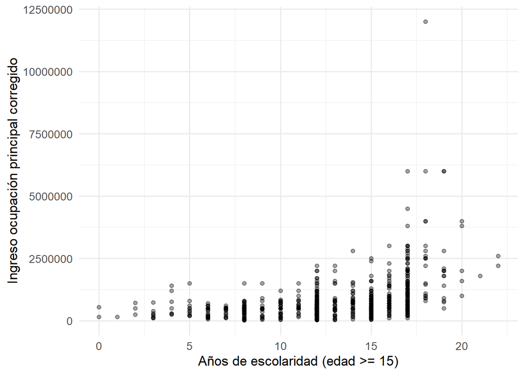

Años de escolaridad e ingreso de la ocupación principal · CASEN 2024

```r
ggplot(datos, aes(                 # Usamos nuestra submuestra
  x = escolaridad,                    # Eje X: años de escolaridad
  y = ingreso_laboral                 # Eje Y: ingreso laboral
)) +
  geom_point()                        # Cada punto representa una persona
```

> **A medida que aumenta la escolaridad, ¿el ingreso parece tender a valores más altos o más bajos?**

> **¿La nube parece seguir una tendencia aproximadamente recta o presenta una forma claramente curva?**

> **¿Hay algún caso que llame especialmente la atención?**

Estas tres preguntas cumplen funciones distintas.

- La primera nos ayuda a pensar en la **dirección** de la asociación.
- La segunda, en su **forma**.
- La tercera nos recuerda que algunos casos pueden alejarse bastante del patrón general.

Los datos reales no forman una línea perfecta. Justamente por eso conviene observar primero la nube completa antes de resumirla mediante un único número.

# 3 Del gráfico a la covarianza

## 3.1 De la posición de cada persona al patrón del conjunto

En el gráfico vimos a todas las personas al mismo tiempo. Ahora queremos entender cómo podemos pasar desde la posición de **cada persona** a un **resumen del patrón** que aparece en el conjunto.

**Nota**

En R, `$` permite elegir una variable dentro de una base. Por ejemplo, `datos$escolaridad` significa **“la variable escolaridad que está dentro de la base datos”**.

```r
mean(datos$escolaridad)      # Promedio de escolaridad
mean(datos$ingreso_laboral)  # Promedio de ingreso
```

[output not shown]

En nuestra submuestra, la escolaridad promedio es aproximadamente **12,8 años** y el ingreso promedio es aproximadamente **$749.203**. Empecemos con una sola variable: **la escolaridad.**

Pensemos primero en una persona con **15 años de escolaridad**. Para saber dónde se encuentra respecto del promedio, restamos su valor menos la media:

> **15 − 12,8 = +2,2**

El resultado **+2,2** significa que esta persona se encuentra aproximadamente 2,2 años **sobre el promedio de escolaridad** de nuestra muestra.

Ahora pensemos en una persona con **10 años de escolaridad**:

> **10 − 12,8 = -2,8**

El signo negativo indica que esta persona se encuentra aproximadamente 2,8 años **bajo el promedio**.

En general, escribimos esta diferencia como:

$$x_i-\bar{x}$$

que puede leerse como:

$$\text{valor de una persona}
-
\text{promedio de la variable}$$

**ImportanteResiduo no es desviación estándar**

En este práctico llamaremos **residuo respecto de la media** a la diferencia entre el valor de una persona y el promedio de la variable. Esta diferencia también puede denominarse **desviación respecto de la media**. No es lo mismo que la **desviación estándar**, que resume la dispersión de todos los casos.

## 3.2 El producto de las desviaciones

Para trabajar con dos variables necesitamos hacer lo mismo con ambas. En nuestra submuestra:

- la escolaridad promedio es **12,8 años**;
- el ingreso laboral promedio es **$749.203**.

Una misma persona ocupa, entonces, **dos posiciones**: una respecto del promedio de escolaridad y otra respecto del promedio de ingreso.

Si una persona está **sobre ambos promedios**, sus dos desviaciones son positivas:

$$(+)(+)=+$$

El producto es positivo porque ambas variables ubican a esa persona del **mismo lado** de sus respectivas medias.

Si una persona está **bajo ambos promedios**, sus dos desviaciones son negativas:

$$(-)(-)=+$$

El producto vuelve a ser positivo: otra vez ambas variables están del mismo lado de sus medias.

En cambio, si una persona está sobre el promedio en una variable y bajo el promedio en la otra:

$$(+)(-)=-$$

el producto es negativo, porque las dos variables ubican al caso en **lados opuestos** de sus medias.

**Importante¿Por qué hacemos esta multiplicación?**

Porque el producto nos entrega una forma compacta de registrar, para **cada persona**, si las dos variables se encuentran del mismo lado de sus medias o en lados opuestos. Además, una persona muy alejada de ambas medias aporta un producto de mayor magnitud que una persona ubicada muy cerca de los promedios.

**Los casos anteriores pueden resumirse así:**

| Escolaridad respecto de su media | Ingreso respecto de su media | Producto |
| --- | --- | --- |
| Sobre | Sobre | Positivo |
| Bajo | Bajo | Positivo |
| Sobre | Bajo | Negativo |
| Bajo | Sobre | Negativo |

Antes de reunir todos los aportes en la covarianza, observemos qué ocurre con una persona a la vez. Seleccionen un punto y fíjense en el signo de sus residuos respecto de ambas medias y en el producto que resulta.

**Explora cómo aporta una persona.** Selecciona un punto para observar cómo su posición respecto de ambas medias determina los signos de sus residuos y del producto resultante.

Caso seleccionado

**Producto de los residuos**

Este producto será uno de los aportes que luego reuniremos para construir el balance general.

Ahora generalicen:

> **¿Qué tienen en común los casos con producto positivo? ¿Y qué ocurre en los casos con producto negativo?**

Cada persona de la muestra aporta un producto como estos. Algunos serán positivos y otros negativos. Pero nuestra pregunta no se refiere a una sola persona: queremos describir el patrón de **toda la muestra**.

> **¿Cómo podemos reunir todos esos aportes en un único número?**

## 3.3 Covarianza

La **covarianza** combina los productos de desviaciones de todas las personas para resumir hacia qué lado queda el balance general.

Después de entender la idea, podemos representar ese procedimiento mediante la fórmula:

$$\operatorname{cov}(X,Y)
=
\frac{
\sum_{i=1}^{n}
(x_i-\bar{x})(y_i-\bar{y})
}{n-1}$$

Podemos leerla paso a paso:

- $(x_i-\bar{x})(y_i-\bar{y})$ es el **aporte de una persona**.
- $\sum$ indica que reunimos los aportes de **todas las personas** (sumatoria).
- $n-1$ aparece en el denominador porque estamos calculando la covarianza a partir de **una muestra**.

**TipLa idea central**

Si el balance de los productos queda del lado **positivo**, la covarianza será positiva.

Si el balance queda del lado **negativo**, la covarianza será negativa.

> **Considerando la nube de puntos y los casos anteriores, ¿qué signo esperarían para la covarianza: positivo o negativo?**

La función `cov()` necesita las dos variables cuya covarianza queremos calcular:

```r
cov(
  datos$escolaridad,       # Años de escolaridad
  datos$ingreso_laboral    # Ingreso laboral
)
```

[output not shown]

La covarianza obtenida es aproximadamente **1.130.120**.

Lo primero que podemos interpretar con facilidad es el **signo**. En nuestra submuestra, el balance general es positivo. Esto indica que los casos con escolaridad relativamente alta tienden a encontrarse acompañados por ingresos relativamente altos, y los casos con escolaridad relativamente baja por ingresos relativamente bajos.

El número completo, en cambio, es difícil de interpretar directamente. No tenemos una escala fija que nos diga si **1.130.120** representa por sí solo una asociación poco o muy marcada.

La covarianza nos ayuda a identificar la **dirección del patrón lineal conjunto**, pero su magnitud depende de las unidades utilizadas. Necesitamos entonces una medida que conserve esta información y coloque el resultado en una **escala común**.

Esa medida es la **correlación de Pearson**.

# 4 De la covarianza a Pearson

## 4.1 Correlación de Pearson

En este contexto, **estandarizar** significa llevar las variaciones a una escala común para que el resultado no dependa de las unidades originales. Queremos una medida que describa el patrón lineal sin cambiar su valor debido a la unidad de medida.

Pearson realiza esa estandarización dividiendo la covarianza por las desviaciones estándar de las dos variables:

$$r=
\frac{
\operatorname{cov}(X,Y)
}{
s_X s_Y
}$$

En clases vimos que el coeficiente de Pearson también puede escribirse mediante otras fórmulas **equivalentes**. Todas producen el mismo valor de (r).

**Mostrar otras fórmulas equivalentes de Pearson**

Al reemplazar la covarianza por su fórmula:

$$r=
\frac{
\sum_{i=1}^{n}(x_i-\bar{x})(y_i-\bar{y})
}{
(n-1)s_X s_Y
}$$

También puede escribirse directamente a partir de las desviaciones respecto de las medias:

$$r=
\frac{
\sum_{i=1}^{n}(x_i-\bar{x})(y_i-\bar{y})
}{
\sqrt{
\left[\sum_{i=1}^{n}(x_i-\bar{x})^2\right]
\left[\sum_{i=1}^{n}(y_i-\bar{y})^2\right]
}
}$$

Las tres expresiones son **equivalentes**. No es necesario memorizar cada una: lo importante es comprender que todas permiten obtener el mismo coeficiente de correlación de Pearson.

Las desviaciones estándar conservan las mismas unidades que las variables originales. Por eso, al dividir, las unidades se cancelan. En nuestro ejemplo:

$$\frac{
\text{años}\times\text{pesos}
}{
\text{años}\times\text{pesos}
}
=
\text{sin unidades}$$

El resultado queda además en una escala fija:

$$-1\leq r\leq1$$

La función `cor()` calcula la **correlación de Pearson** entre dos variables cuantitativas:

```r
cor(
  datos$escolaridad,       # Escolaridad
  datos$ingreso_laboral    # Ingreso laboral
)
```

```
[1] 0.4244602
```

Pearson produce un coeficiente comparable que **no depende de si expresamos el ingreso en pesos o en miles de pesos**. Esto es posible porque el coeficiente está **estandarizado**.

## 4.2 Cómo interpretar $r$

Para interpretar Pearson necesitamos responder dos preguntas diferentes.

**1. ¿En qué dirección aparece el patrón?**

El **signo** de $r$ indica la dirección:

$$r>0 \rightarrow \text{asociación directa (positiva)}$$

$$r<0 \rightarrow \text{asociación inversa (negativa)}$$

**2. ¿Qué tan marcado es el patrón lineal?**

Observamos el valor absoluto:

$$|r|$$

Un **patrón lineal** es aquel cuya tendencia general puede resumirse razonablemente mediante una dirección aproximadamente recta. Esto no significa que todos los puntos deban encontrarse exactamente sobre una línea.

Cuanto más cerca de $1$ se encuentra $|r|$, más marcado es ese patrón lineal; cuanto más cerca de $0$, menos marcado es.

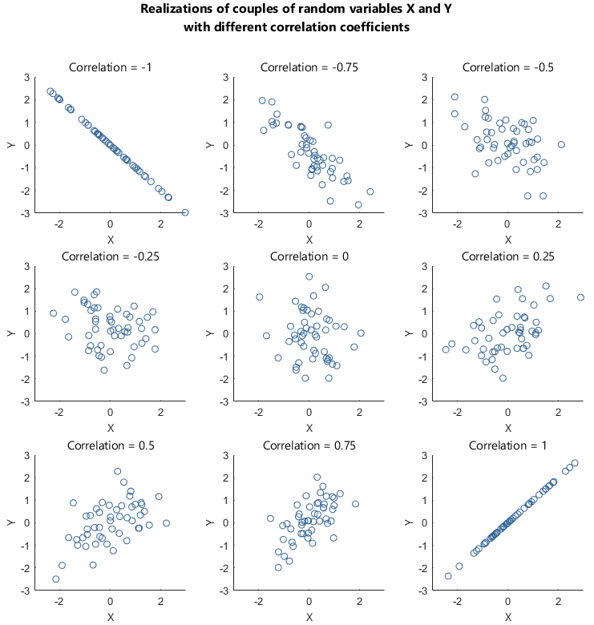

Ejemplos de distintos valores del coeficiente de correlación de Pearson.

**AdvertenciaInterpretación**

En esta submuestra de CASEN 2024, la correlación entre escolaridad e ingreso de la ocupación principal es $r=$ **0,42** y su dirección es **positiva**. En términos sustantivos, las personas con mayor escolaridad tienden a presentar ingresos más altos.

> **El valor de $r$ indica qué tan marcado es ese patrón lineal en los casos analizados, pero sigue existiendo variabilidad entre las personas.**

Volvamos ahora a la nube de puntos. Para ayudarnos a visualizar la dirección general del patrón agregaremos una **línea de tendencia lineal**, que nos ayuda a visualizar la tendencia lineal que Pearson resume mediante un coeficiente.

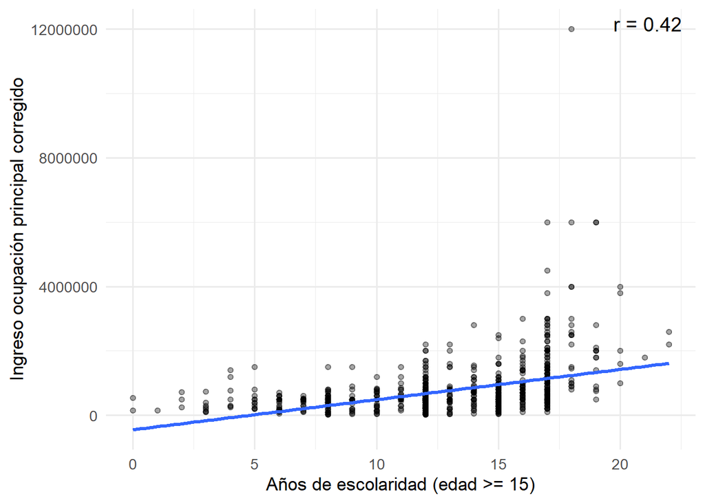

Nota: La línea muestra la tendencia lineal general de los datos. No es la correlación y su pendiente no corresponde al valor de r; solo ayuda a visualizar el patrón lineal que Pearson resume numéricamente.

Esta asociación **no demuestra por sí sola que una variable cause la otra**.

**ImportantePara interpretar r**

**Signo** $\rightarrow$ dirección de la asociación.  
**$|r|$** $\rightarrow$ qué tan marcado es el patrón **lineal**.

# 5 Por qué debemos mirar el gráfico

## 5.1 Limitaciones de Pearson

Para aislar algunas limitaciones de Pearson utilizaremos ahora ejemplos didácticos construidos específicamente para mostrar cada situación. La rutina será la misma: **mirar → anticipar → calcular → volver a mirar**.

**1. Una relación no lineal**

Aquí existe un patrón claro entre $X$ e $Y$, pero su forma es curva:

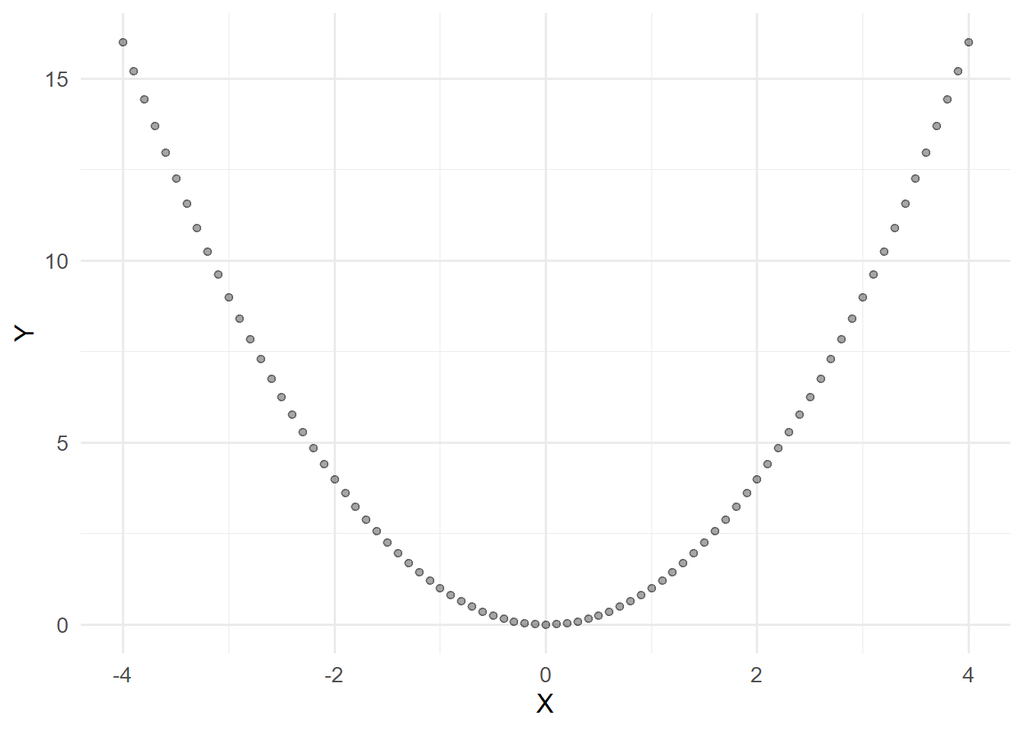

> **Si existe un patrón evidente, ¿qué esperan que ocurra con Pearson cuando ese patrón no es lineal?**

```
[1] 0.0000000000000001633663
```

El valor es aproximadamente 0. Esto no significa que las variables carezcan de relación: significa que **no presentan una asociación lineal marcada**.

**2. Un valor extremo**

Comparemos un patrón lineal claro con el mismo conjunto después de agregar una sola observación extrema:

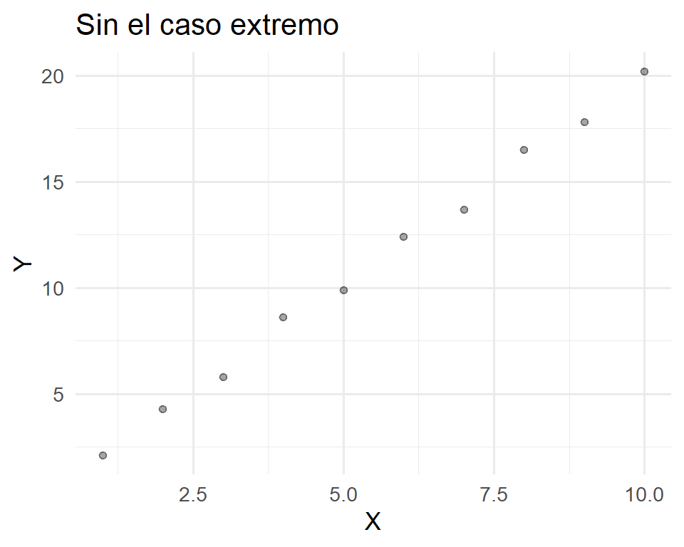

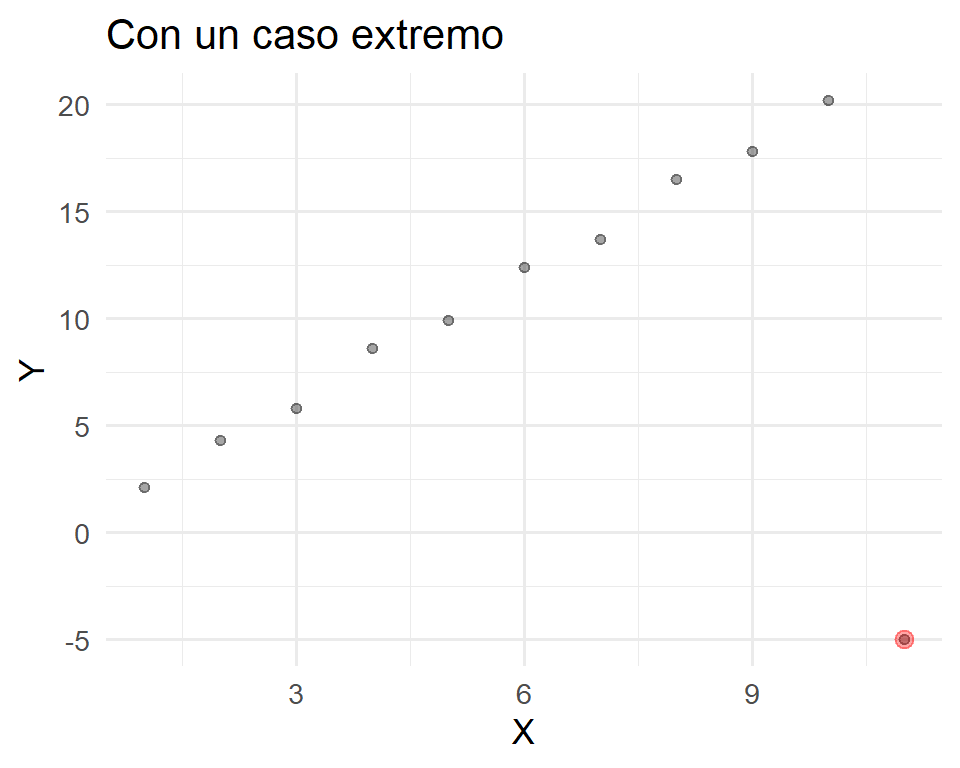

| Escenario | r |
| --- | --- |
| Sin caso extremo | 0.999 |
| Con caso extremo | 0.336 |

> **¿Cambió el patrón de la mayoría de los puntos? ¿Qué ocurrió con $r$ al agregar una sola observación?**

Pearson puede ser sensible a valores extremos. Por eso, incluso después de calcular $r$, necesitamos volver al gráfico.

**3. Un mismo $r$, patrones distintos**

El cuarteto de Anscombe contiene cuatro conjuntos con resúmenes numéricos muy parecidos, incluida una correlación prácticamente igual, pero con formas gráficas muy distintas:

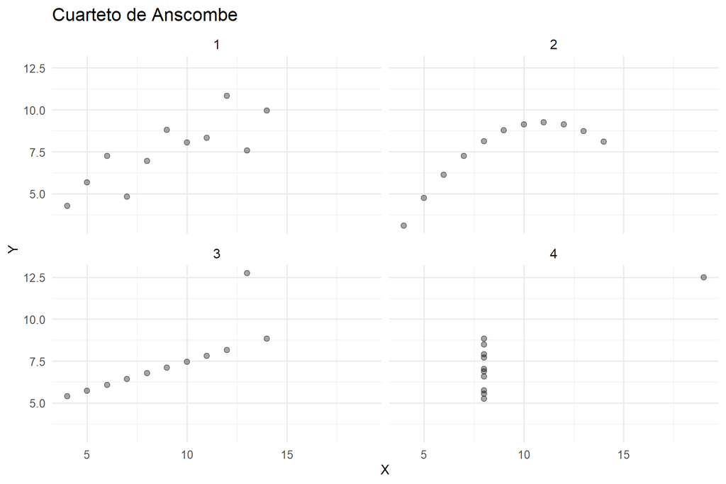

| Conjunto | r |
| --- | --- |
| 1 | 0.816 |
| 2 | 0.816 |
| 3 | 0.816 |
| 4 | 0.817 |

> **¿Qué perderíamos si observáramos solamente los coeficientes y no los gráficos?**

**Un coeficiente resume los datos, pero no reemplaza mirar los datos.**

**4. Correlación no implica causalidad**

Hasta ahora hemos usado la correlación de Pearson para describir **cómo se relacionan dos variables**. Sin embargo, encontrar una correlación no significa que una variable sea la causa de la otra.

Una asociación puede aparecer porque existe una **tercera variable** relacionada con ambas.

Por ejemplo, imaginemos que observamos una asociación positiva entre:

- el **tamaño del calzado** de niños y niñas;
- su **capacidad de lectura**.

Esto no significa que tener pies más grandes mejore la lectura. Ambas variables cambian con una tercera variable: la **edad**.

$$\text{Edad}
\longrightarrow
\begin{cases}
\text{Tamaño del calzado} \\
\text{Capacidad de lectura}
\end{cases}$$

En este tipo de situaciones podemos observar una **correlación espuria**: existe una asociación entre dos variables, pero esa asociación puede explicarse por la influencia de otra variable.

**ImportanteCorrelación no es causalidad**

La correlación de Pearson nos dice **en qué dirección y qué tan marcado es el patrón lineal entre dos variables**.

Por sí sola, no permite concluir que una variable cause cambios en la otra.

# 6 Ejercicio Autónomo

Ahora analizarán una pregunta nueva utilizando **exactamente la misma submuestra de 1.000 casos de CASEN 2024**:

> **¿En qué medida las horas trabajadas habitualmente por semana y el ingreso de la ocupación principal se encuentran asociados?**

Esta vez deberán recorrer la secuencia con mayor autonomía.

**1. Observen**

Construyan la nube de puntos completando solamente las variables:

```r
ggplot(datos, aes(                 # Usen la misma submuestra
  x = __________,                     # Completen la variable del eje X
  y = __________                      # Completen la variable del eje Y
)) +
  geom_point()                        # Cada punto representa una persona
```

> **¿A medida que aumentan las horas de trabajo, el ingreso parece tender a valores más altos o más bajos?**

**2. Evalúen la forma**

> **¿El patrón parece aproximadamente lineal o presenta otra forma clara?**

**3. Anticipen**

> **¿Qué signo esperan obtener para $r$?**

**4. Calculen**

```r
cor(
  datos$__________,  # Completen la primera variable
  datos$__________     # Completen la segunda variable
)
```

**5. Interpreten**

En una conclusión breve respondan:

- ¿qué les dice el **signo** de $r$?.
- ¿qué les dice su **magnitud** sobre el patrón lineal?.
- ¿cómo expresarían sustantivamente la asociación observada entre horas habituales de trabajo e ingreso **en la submuestra analizada**?

**6. Vuelvan al gráfico**

> **¿El coeficiente representa razonablemente el patrón observado en el scatterplot? Justifiquen brevemente.**

# 7 Para cerrar

La secuencia utilizada durante el práctico puede resumirse así:

| Paso | Pregunta |
| --- | --- |
| **Pregunta** | ¿Qué dos variables queremos relacionar? |
| **Gráfico** | ¿Qué patrón observamos? |
| **Posición** | ¿Cómo se ubican los casos respecto de las medias? |
| **Covarianza** | ¿Qué signo presenta el balance de los productos? |
| **Pearson** | ¿Qué valor toma $r$ y qué nos dice? |
| **Evaluación** | ¿El coeficiente representa bien lo que vemos? |

> **La correlación resume un patrón lineal. No reemplaza mirar los datos.**